# Data Vis. Mini-Project

Yasshin Lozano

#### **The Big Idea**

The Big idea would be to provide the personnel and students of St. Thomas University with detailed information about card activity on campus.

#### **Who?**

The audience of this visualization would be the security faculty, the Provost, or basically anyone that can benefit from this information.

#### **What?**

I want to give insight on opening up the gate on 32nd to relieve some traffic from the gate on 37th. Maybe they don’t have to open it up everyday, but at least from Tuesday through Wednesday. My visualization will provide the exact numbers for each day to back up my opinion.

#### **How?**

First I wanted to show a sort of heat map or density map to display the activity in each location an ID card is used. From there I would show what days of the week are the most students coming into the campus. If I figure out what day most students come in, I can then figure out what time the majority of students come in. Based on my findings, most students this semester have class on Tuesdays. Now that can tell us a couple of things such as having certain events on this specific day to have more participants, opening up the gate on 32nd, and maybe having a bit more staff for lunch. The options are endless.

```r
library(tidyverse)
library(ggmap)
library(maps)
library(mapproj)
library(readxl)
library(lubridate) # Handle Date and Time
library(plotly) # Interactive graphs
library(stringr)# wrap text
GD <- read_excel("E:/Users/lozan/Desktop/Gate_Data/Gate.xls")
```

```r
head(GD)
```

| Event | Location | lon | lat | Event_timestamp |
| --- | --- | --- | --- | --- |
| Access granted | 37th Ave Gate | -80.26011 | 25.92354 | 2018-04-19 10:11:05 |
| Access granted | 37th Ave Gate | -80.26011 | 25.92354 | 2018-04-19 10:11:05 |
| Access granted | Science Bldg | -80.25381 | 25.92399 | 2018-04-19 10:11:03 |
| Access granted | Science Bldg | -80.25381 | 25.92399 | 2018-04-19 10:11:03 |
| Access granted | Science Bldg | -80.25381 | 25.92399 | 2018-04-19 10:11:01 |
| Access granted | Science Bldg | -80.25381 | 25.92399 | 2018-04-19 10:11:01 |

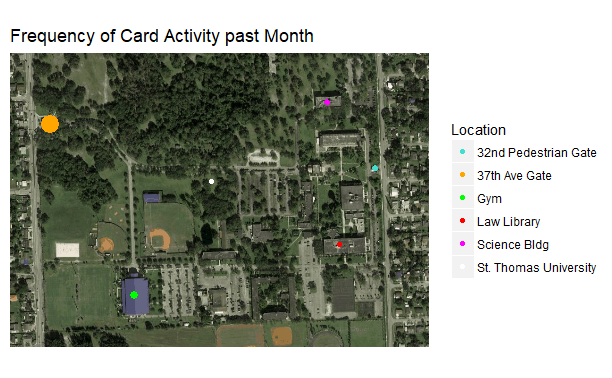

```r
geoc <- geocode("St Thomas University FL, Miami")
# Satellite Image of STU in Miami, FL
map2 <- get_map(location = c(-80.256783,25.922350), zoom = 16, maptype = "satellite")
ggmap(map2, extent = "normal") +
  geom_point(data = GD, aes(x = lon, y = lat, color = Location)) +
  geom_count(data = GD, aes(x = lon, y = lat,fill = Location, color = Location), show.legend = FALSE) +
  scale_x_continuous(limits = c(-80.261, -80.2515), expand = c(0, 0)) +
  scale_y_continuous(limits = c(25.919, 25.925), expand = c(0, 0)) +
  ggtitle("Frequency of Card Activity past Month") +
  theme(axis.title.x = element_blank(),
        axis.text.x = element_blank(),
        axis.ticks.x = element_blank(),
        axis.title.y = element_blank(),
        axis.text.y = element_blank(),
        axis.ticks.y = element_blank()) +
  scale_color_manual(values = c("32nd Pedestrian Gate" = "turquoise", "37th Ave Gate" = "orange", "Gym" = "green", "Law Library" = "red", "Science Bldg" = "magenta", "St. Thomas University" = "white"))
```

```r
GateDT <- ymd_hms(GD$Event_timestamp)
Day_of_Week <- wday(GateDT, label = TRUE)
Hours_of_Week <- hour(GateDT)
```

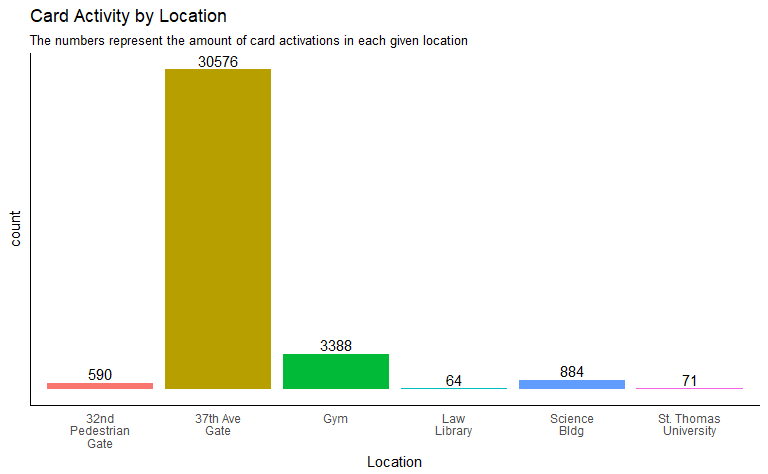

```r
# Busiest Location
ggplot(data = GD,aes(x = Location)) +
  geom_bar(aes(fill=Location), show.legend = FALSE)  +
  theme_classic()+
  theme(axis.text.x = element_text(),
        axis.ticks = element_blank(),
        axis.text.y = element_blank()) +
  geom_text(stat = "count", aes(label=..count..), vjust = -0.3) +
  scale_x_discrete(labels = function(x) str_wrap(x, width = 10)) +
  ggtitle("Card Activity by Location", subtitle = "The numbers represent the amount of card activations in each given location")
```

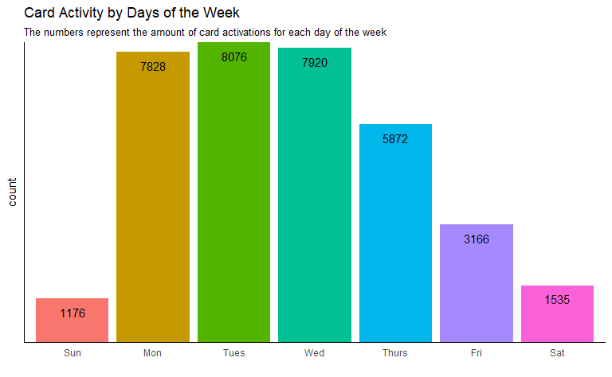

```r
# Busiest days of the week
ggplot(data = GD,aes(x = Day_of_Week)) +
  geom_bar(aes(fill=Day_of_Week), show.legend = FALSE)  +
  theme_classic()+
  theme(axis.text.x = element_text(),
        axis.ticks = element_blank(),
        axis.text.y = element_blank()) +
  xlab("") +
  geom_text(stat = "count", aes(label=..count..), vjust = 1.9) +
  scale_x_discrete(labels = function(x) str_wrap(x, width = 10)) +
  scale_y_continuous(expand = c(0,0)) +
  ggtitle("Card Activity by Days of the Week", subtitle = "The numbers represent the amount of card activations for each day of the week")
```

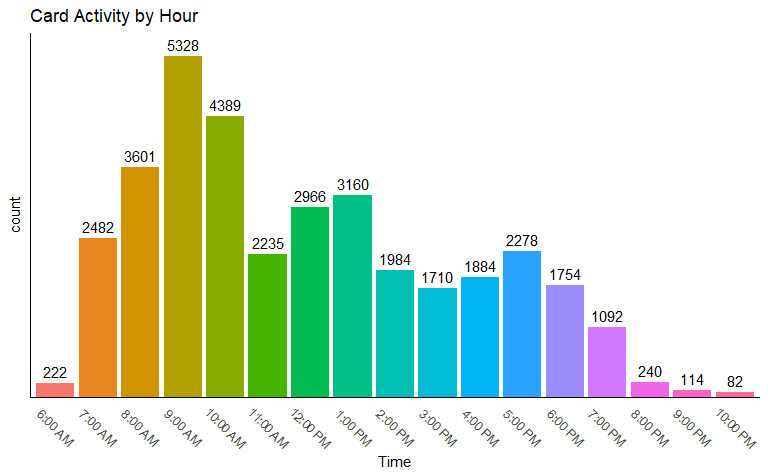

```r
Factored_Week <- as.factor(Hours_of_Week)
# Busiest hour
ggplot(data=GD, aes(x=Factored_Week)) +
  geom_bar(aes(fill=Factored_Week), show.legend = FALSE) +
  geom_text(stat = "count", aes(label=..count..), vjust=-0.5) +
  scale_y_continuous(limits = c(0, 5700), expand = c(0,0)) +
  scale_x_discrete(limit = c("6","7","8","9","10","11","12","13","14","15","16","17","18","19","20","21","22"), labels = c("6:00 AM","7:00 AM","8:00 AM","9:00 AM","10:00 AM","11:00 AM","12:00 PM","1:00 PM","2:00 PM","3:00 PM","4:00 PM","5:00 PM","6:00 PM","7:00 PM","8:00 PM","9:00 PM","10:00 PM"))  +
  theme_classic() +
  theme(axis.text.x = element_text(angle=-45, vjust =0.45),
        axis.text.y = element_blank(),
        axis.ticks = element_blank()) +
  ggtitle("Card Activity by Hour") +
  xlab("Time")
```